# Wheat_Futures_ML

### Import Libraries

We draw on Python packages for data manipulation and modeling. Most important are Polars, a high-performance alternative to Pandas for data manipulation, and Scikit-Learn for machine learning study design and modeling algorithms.

```python
import os

# import Python packages
import numpy as np
import pyarrow # foundation for polars
import polars as pl # pandas DataFrame utilities
import pandas as pd # pandas DataFrame utilities

# Preprocessing
from sklearn.preprocessing import MinMaxScaler, StandardScaler
from sklearn.pipeline import Pipeline
from sklearn.model_selection import (RandomizedSearchCV,
                                    TimeSeriesSplit)
from sklearn.model_selection import cross_validate

# utilized in all possible subsets classification work
from sklearn.linear_model import LogisticRegression
from sklearn.metrics import log_loss

# needed for randomized search
from sklearn.model_selection import RandomizedSearchCV
from scipy.stats import randint, uniform

# metrics in xgboost tuning and final model evaluation
from sklearn.metrics import (accuracy_score,
                             classification_report,
                             roc_curve,
                             roc_auc_score,
                             RocCurveDisplay,
                             ConfusionMatrixDisplay,
                             confusion_matrix,
                             precision_score,
                             recall_score,
                             f1_score)

# XGBoost Package... more complete than SciKit-Learn boosting methods
import xgboost as xgb
from xgboost import XGBRegressor, XGBClassifier, plot_importance

# package for downloading historical market data
import yfinance as yf

# Plotting
import matplotlib.pyplot as plt
# Display static plots directly in the notebook output
%matplotlib inline
# create stylized visualizations, including heat maps
import seaborn as sns

#Iterations
from itertools import chain, combinations

import warnings
# Suppress warnings for cleaner output
warnings.filterwarnings('ignore')
warnings.simplefilter(action='ignore', category=FutureWarning)
```

```python
df = pl.read_csv('Wheat-features.csv')
df.head()
```

shape: (5, 25)

| Date str | Open f64 | High f64 | Low f64 | Close f64 | Volume i64 | CloseLag1 f64 | CloseLag2 f64 | CloseLag3 f64 | HML f64 | HMLLag1 f64 | HMLLag2 f64 | HMLLag3 f64 | OMC f64 | OMCLag1 f64 | OMCLag2 f64 | OMCLag3 f64 | VolumeLag1 i64 | VolumeLag2 i64 | VolumeLag3 i64 | CloseEMA2 f64 | CloseEMA4 f64 | CloseEMA8 f64 | LogReturn f64 | Target i64 |
| --- | --- | --- | --- | --- | --- | --- | --- | --- | --- | --- | --- | --- | --- | --- | --- | --- | --- | --- | --- | --- | --- | --- | --- | --- |
| "2000-07-20" | 244.0 | 247.5 | 244.0 | 247.0 | 3792 | 245.0 | 241.25 | 244.0 | 3.5 | 7.0 | 6.5 | 4.25 | -3.0 | -3.75 | 3.0 | 4.0 | 7136 | 6523 | 7233 | 243.785714 | 243.572044 | 243.484904 | 0.00813 | 1 |
| "2000-07-21" | 247.0 | 248.5 | 246.5 | 247.25 | 4380 | 247.0 | 245.0 | 241.25 | 2.0 | 3.5 | 7.0 | 6.5 | -0.25 | -3.0 | -3.75 | 3.0 | 3792 | 7136 | 6523 | 245.5 | 244.910744 | 244.603433 | 0.001012 | 1 |
| "2000-07-24" | 247.25 | 249.5 | 242.5 | 245.5 | 4393 | 247.25 | 247.0 | 245.0 | 7.0 | 2.0 | 3.5 | 7.0 | 1.75 | -0.25 | -3.0 | -3.75 | 4380 | 3792 | 7136 | 246.403226 | 245.743024 | 245.329992 | -0.007103 | 0 |
| "2000-07-25" | 244.75 | 247.0 | 243.0 | 245.5 | 5973 | 245.5 | 247.25 | 247.0 | 4.0 | 7.0 | 2.0 | 3.5 | -0.75 | 1.75 | -0.25 | -3.0 | 4393 | 4380 | 3792 | 245.944444 | 245.661675 | 245.371834 | 0.0 | 0 |
| "2000-07-26" | 245.5 | 247.5 | 243.0 | 244.25 | 3755 | 245.5 | 245.5 | 247.25 | 4.5 | 4.0 | 7.0 | 2.0 | 1.25 | -0.75 | 1.75 | -0.25 | 5973 | 4393 | 4380 | 245.720472 | 245.60973 | 245.400853 | -0.005105 | 0 |

### Feature List

Features or explanatory variables, also known as an independent variables, are used to predict the values of target variables. The initial list of featrues includes the price-based features defined above, everything except the continuous response **LogReturn** if we wanted to employ regression and the binary response **Target** for classification, which is the focus of this project. This complete feature list is used in evaluating all methods.

```python
# Select Features for the Model, exclude current day price variables ... no "leakage"
# note for moving averages, we have excluded the current day, and provide a 10-day gap
# so these may be included in the set
X = df.drop(['Date', 'LogReturn', 'Target', 'Open', 'High', 'Low', 'Close', 'Volume', 'HML', 'OMC'])
X.head()
```

shape: (5, 15)

| CloseLag1 f64 | CloseLag2 f64 | CloseLag3 f64 | HMLLag1 f64 | HMLLag2 f64 | HMLLag3 f64 | OMCLag1 f64 | OMCLag2 f64 | OMCLag3 f64 | VolumeLag1 i64 | VolumeLag2 i64 | VolumeLag3 i64 | CloseEMA2 f64 | CloseEMA4 f64 | CloseEMA8 f64 |
| --- | --- | --- | --- | --- | --- | --- | --- | --- | --- | --- | --- | --- | --- | --- |
| 245.0 | 241.25 | 244.0 | 7.0 | 6.5 | 4.25 | -3.75 | 3.0 | 4.0 | 7136 | 6523 | 7233 | 243.785714 | 243.572044 | 243.484904 |
| 247.0 | 245.0 | 241.25 | 3.5 | 7.0 | 6.5 | -3.0 | -3.75 | 3.0 | 3792 | 7136 | 6523 | 245.5 | 244.910744 | 244.603433 |
| 247.25 | 247.0 | 245.0 | 2.0 | 3.5 | 7.0 | -0.25 | -3.0 | -3.75 | 4380 | 3792 | 7136 | 246.403226 | 245.743024 | 245.329992 |
| 245.5 | 247.25 | 247.0 | 7.0 | 2.0 | 3.5 | 1.75 | -0.25 | -3.0 | 4393 | 4380 | 3792 | 245.944444 | 245.661675 | 245.371834 |
| 245.5 | 245.5 | 247.25 | 4.0 | 7.0 | 2.0 | -0.75 | 1.75 | -0.25 | 5973 | 4393 | 4380 | 245.720472 | 245.60973 | 245.400853 |

### Examine the Distribution of LogReturn Values

```python
# Define and examine the target for regression model development
print(df['LogReturn'].describe())

y = np.array(df['LogReturn'])
```

```
shape: (9, 2)
┌────────────┬───────────┐
│ statistic  ┆ value     │
│ ---        ┆ ---       │
│ str        ┆ f64       │
╞════════════╪═══════════╡
│ count      ┆ 6313.0    │
│ null_count ┆ 0.0       │
│ mean       ┆ 0.000119  │
│ std        ┆ 0.020373  │
│ min        ┆ -0.112971 │
│ 25%        ┆ -0.01239  │
│ 50%        ┆ -0.000533 │
│ 75%        ┆ 0.011736  │
│ max        ┆ 0.197014  │
└────────────┴───────────┘
```

### Standardize All Features

Standardization is carried out for the complete set of features.

```python
# Standardize features
featureNames = X.columns
print("Feature names correspond to Numpy array columns:",featureNames)
scaler = StandardScaler()
X = scaler.fit_transform(np.array(X))
```

```
Feature names correspond to Numpy array columns: ['CloseLag1', 'CloseLag2', 'CloseLag3', 'HMLLag1', 'HMLLag2', 'HMLLag3', 'OMCLag1', 'OMCLag2', 'OMCLag3', 'VolumeLag1', 'VolumeLag2', 'VolumeLag3', 'CloseEMA2', 'CloseEMA4', 'CloseEMA8']
```

### Target Definition for Classification (Target)

Identify the binary target variable for model development.

```python
# Define and examine the target for classification model development
print(df['Target'].value_counts())

y = np.array(df['Target'])
```

```
shape: (2, 2)
┌────────┬───────┐
│ Target ┆ count │
│ ---    ┆ ---   │
│ i64    ┆ u32   │
╞════════╪═══════╡
│ 0      ┆ 3302  │
│ 1      ┆ 3011  │
└────────┴───────┘
```

### Feature Selection Using All Possible Classifications

We draw on traditional applied statistis, selecting the best combination of features using the Akaike Information Criterion (AIC).

```python
# Polars DataFrame for storing results from all possible subsets
resultsSchema = {"trialNumber": pl.Int64, "features": pl.String, 'aic': pl.Float64}
resultsDataFrame = pl.DataFrame(schema = resultsSchema)

def getAIC(X, y):
    model = LogisticRegression()
    model.fit(X, y)
    # Calculate log-likelihood
    loglik = -log_loss(y, model.predict_proba(X)) * len(y)
    # Calculate the number of parameters
    k = X.shape[1] + 1
    # Calculate AIC... smaller is better
    aic = 2 * k -2 * loglik
    # print(f"AIC: {aic}") # print for initial testing
    return aic

def powerset(iterable):
    s = list(iterable)
    return chain.from_iterable(combinations(s, r) for r in range(1, len(s)))

trialNumber = 0 # initialize count
for c in powerset(range(X.shape[1])):
    trialNumber = trialNumber + 1
    # print(c)
    thisAIC = getAIC(X[:,c], y)
    thisTrialDataFrame = pl.DataFrame({"trialNumber": trialNumber,
                                       "features": ' '.join(map(str, c)),
                                       "aic": thisAIC},
                                        schema=resultsSchema)
    resultsDataFrame = pl.concat([resultsDataFrame,thisTrialDataFrame])

# one more set of features... all features
trialNumber = trialNumber + 1
thisAIC = getAIC(X, y)
thisTrialDataFrame = pl.DataFrame({"trialNumber": trialNumber,
                                   "features": "0 1 2 3 4 5 6 7 8 9 10 11 12 13 14",
                                   "aic": thisAIC},
                                    schema=resultsSchema, strict=False)
resultsDataFrame = pl.concat([resultsDataFrame,thisTrialDataFrame])
```

```python
print(resultsDataFrame.sort('aic').head(10))
```

```
shape: (10, 3)
┌─────────────┬───────────────┬─────────────┐
│ trialNumber ┆ features      ┆ aic         │
│ ---         ┆ ---           ┆ ---         │
│ i64         ┆ str           ┆ f64         │
╞═════════════╪═══════════════╪═════════════╡
│ 922         ┆ 0 9 10 13     ┆ 8736.505627 │
│ 923         ┆ 0 9 10 14     ┆ 8737.173083 │
│ 2594        ┆ 0 3 9 10 13   ┆ 8737.582429 │
│ 28          ┆ 0 13          ┆ 8737.616861 │
│ 2889        ┆ 0 7 9 10 13   ┆ 8737.636924 │
│ 1540        ┆ 3 6 9 10      ┆ 8737.668231 │
│ 6256        ┆ 0 3 4 9 10 13 ┆ 8737.749358 │
│ 2429        ┆ 0 2 9 10 13   ┆ 8737.871944 │
│ 2714        ┆ 0 4 9 10 13   ┆ 8737.950651 │
│ 505         ┆ 6 9 10        ┆ 8737.98513  │
└─────────────┴───────────────┴─────────────┘
```

### Selected Feature Subset

```
shape: (7, 7)
┌───────────┬───────────┬──────────┬────────────┬────────────┬───────────┬───────────┐
│ LogReturn ┆ CloseLag1 ┆ HMLLag1  ┆ VolumeLag1 ┆ VolumeLag2 ┆ CloseEMA4 ┆ CloseEMA8 │
│ ---       ┆ ---       ┆ ---      ┆ ---        ┆ ---        ┆ ---       ┆ ---       │
│ f64       ┆ f64       ┆ f64      ┆ f64        ┆ f64        ┆ f64       ┆ f64       │
╞═══════════╪═══════════╪══════════╪════════════╪════════════╪═══════════╪═══════════╡
│ 1.0       ┆ -0.040224 ┆ -0.04183 ┆ -0.01674   ┆ -0.031097  ┆ -0.040007 ┆ -0.03911  │
│ -0.040224 ┆ 1.0       ┆ 0.707357 ┆ 0.341136   ┆ 0.340154   ┆ 0.997239  ┆ 0.993576  │
│ -0.04183  ┆ 0.707357  ┆ 1.0      ┆ 0.350039   ┆ 0.307214   ┆ 0.698884  ┆ 0.692166  │
│ -0.01674  ┆ 0.341136  ┆ 0.350039 ┆ 1.0        ┆ 0.891454   ┆ 0.339618  ┆ 0.337888  │
│ -0.031097 ┆ 0.340154  ┆ 0.307214 ┆ 0.891454   ┆ 1.0        ┆ 0.34027   ┆ 0.338791  │
│ -0.040007 ┆ 0.997239  ┆ 0.698884 ┆ 0.339618   ┆ 0.34027    ┆ 1.0       ┆ 0.998766  │
│ -0.03911  ┆ 0.993576  ┆ 0.692166 ┆ 0.337888   ┆ 0.338791   ┆ 0.998766  ┆ 1.0       │
└───────────┴───────────┴──────────┴────────────┴────────────┴───────────┴───────────┘
```

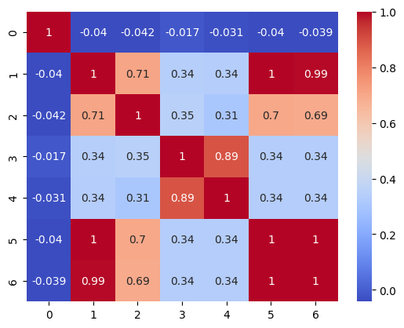

```python
# examine relationships among five selected features, along with LogReturn and CloseLag1
XStudy = df.select('LogReturn','CloseLag1','HMLLag1','VolumeLag1','VolumeLag2','CloseEMA4','CloseEMA8')

# prepare correlation heat map using seaborn
corrMatrix = XStudy.corr()
print(corrMatrix)
sns.heatmap(corrMatrix, cmap='coolwarm', annot=True)
plt.show()
```

```python
# select subset of five columns as features
X = df.select('HMLLag2','OMCLag3','VolumeLag1','VolumeLag2','VolumeLag3')
```

### Define Cross-Validation Training and Test Sets

Recognizing that time series observations are not independent observations, we use Scikit-Learn TimeSeriesSplit for cross-validation.

This cross-validation object is a variation of multi-fold cross-validation for independent observations. In the kth split, it returns first k folds as train set and the (k+1)th fold as test set.

Unlike cross-validation for independent observations, however, successive training sets are supersets of those that come before them. A listing of observation index numbers shows what this means for the time series market data in this demonstration.

```python
# Splitting the datasets into train and test sets
# gap is the number of samples to exclude from
# the end of each train set and before the next test set.
tscv = TimeSeriesSplit(gap=10, n_splits=5)

all_splits = list(tscv.split(X, y))
train_0, test_0 = all_splits[0]
train_1, test_1 = all_splits[1]
train_2, test_2 = all_splits[2]
train_3, test_3 = all_splits[3]
train_4, test_4 = all_splits[4]

# examine the objects created for cross-validation splits
print("type(all_splits):", type(all_splits), " outer list length", len(all_splits))
print()
print("train_0 has",len(train_0),"with indices from ",min(train_0),"to",max(train_0))
print("test_0 has",len(test_0),"with indices from ",min(test_0),"to",max(test_0))
print()
print("train_1 has",len(train_1),"with indices from ",min(train_1),"to",max(train_1))
print("test_1 has",len(test_1),"with indices from ",min(test_1),"to",max(test_1))
print()
print("train_2 has",len(train_2),"with indices from ",min(train_2),"to",max(train_2))
print("test_2 has",len(test_2),"with indices from ",min(test_2),"to",max(test_2))
print()
print("train_3 has",len(train_3),"with indices from ",min(train_3),"to",max(train_3))
print("test_3 has",len(test_3),"with indices from ",min(test_3),"to",max(test_3))
print()
print("train_4 has",len(train_4),"with indices from ",min(train_4),"to",max(train_4))
print("test_4 has",len(test_4),"with indices from ",min(test_4),"to",max(test_4))

# to see all indices we can uncomment these statements
# print("elements of all_splits list of lists,\n shows index numbers for each the five lists")
# print(all_splits)
```

```
type(all_splits): <class 'list'>  outer list length 5

train_0 has 1043 with indices from  0 to 1042
test_0 has 1052 with indices from  1053 to 2104

train_1 has 2095 with indices from  0 to 2094
test_1 has 1052 with indices from  2105 to 3156

train_2 has 3147 with indices from  0 to 3146
test_2 has 1052 with indices from  3157 to 4208

train_3 has 4199 with indices from  0 to 4198
test_3 has 1052 with indices from  4209 to 5260

train_4 has 5251 with indices from  0 to 5250
test_4 has 1052 with indices from  5261 to 6312
```

### Define an Initial Classification Model to Be Evaluated¶

We again select gradient boosting from the XGBoost package, this time defining a classification model to be evaluated. Hyperparameters are retained at defauld settings, except for n_estimators.

```python
model = XGBClassifier(objective='binary:logistic', n_estimators=1000, random_state=2025)
```

### Evaluate a Classification Model Within the Time Series Cross-Validation Design

Prior to executing a full-blown search for the "best" classification model, we test the cross-validation design on a binary classification model, revising code provided in online documentation for Scikit-Learn: [Time-related feature engineering](https://canvas.northwestern.edu/courses/240685/assignments/1626616?module_item_id=3530554). In particular, we define appropriate metrics for assessing classification performance.

```python
def evaluate(model, X, y, cv, model_prop=None, model_step=None):
    cv_results = cross_validate(
        model,
        X,
        y,
        cv=cv,
        scoring=["accuracy"],
        return_estimator=model_prop is not None,
    )
    if model_prop is not None:
        if model_step is not None:
            values = [
                getattr(m[model_step], model_prop) for m in cv_results["estimator"]
            ]
        else:
            values = [getattr(m, model_prop) for m in cv_results["estimator"]]
        print(f"Mean model.{model_prop} = {np.mean(values)}")
    accuracy = -cv_results["test_accuracy"]

    # print used in earlier testing
    # print(
    #    f"Mean Accuracy:     {-accuracy.mean():.3f} +/- {accuracy.std():.3f}\n"
    # )
    return (-accuracy.mean(), accuracy.std())

evaluate(model, X, y, cv=tscv, model_prop="n_estimators")
```

```
Mean model.n_estimators = 1000.0
```

```
(0.500190114068441, 0.01865056801282239)
```

```python
# print results from evaluate
accuracyMean, accuracyStd = evaluate(model, X, y, cv=tscv, model_prop="n_estimators")
print(
        f"Mean Accuracy:     {accuracyMean:.3f} +/- {accuracyStd:.3f}\n"
     )
```

```
Mean model.n_estimators = 1000.0
Mean Accuracy:     0.500 +/- 0.019
```

### Randomized Search for Hyperparameter Settings

We search for effective values on five XGBoost hyperparameters: max_depth, min_child_weight, subsample, learning_rate, and n_estimators.

```python
# Randomized search to find the best set of hyperparameters

param_dist = {
    'max_depth': randint(3, 10),
    'min_child_weight': randint(1, 10),
    'subsample': uniform(0.5, 1),
    'learning_rate': uniform(0.01, 0.1),
    'n_estimators': randint(100, 1000),
}
xgb_model = xgb.XGBClassifier(objective='binary:logistic', use_label_encoder=False, eval_metric='logloss', random_state=2025)

random_search = RandomizedSearchCV(
    estimator=xgb_model,
    param_distributions=param_dist,
    n_iter=100, # Number of parameter settings that are sampled.
    scoring='accuracy',
    cv = TimeSeriesSplit(gap=10, n_splits=5),
    random_state=2025,
    n_jobs=-1 # Use all available cores
)

random_search.fit(X, y)

print("Best parameters:", random_search.best_params_)
print("Best score:", random_search.best_score_)
```

[output not shown]

[output cut: 1005 more lines]

[output not shown]

```
Best parameters: {'learning_rate': 0.0802775782402871, 'max_depth': 5, 'min_child_weight': 6, 'n_estimators': 517, 'subsample': 0.8367882286973474}
Best score: 0.5117870722433461
```

### Evaluate the Model

```
<sklearn.metrics._plot.roc_curve.RocCurveDisplay at 0x333c8b910>
```

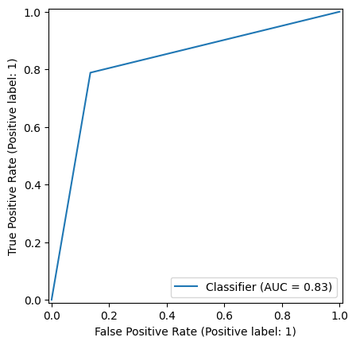

```python
# final model evaluation
finalModel = XGBClassifier(objective='binary:logistic', eval_metric='logloss', random_state=2025,
                          max_depth = 9, min_child_weight = 9, subsample = 0.50, learning_rate = 0.09, n_estimators = 273)

finalModel.fit(X, y)
ypred = finalModel.predict(X)
RocCurveDisplay.from_predictions(y, ypred)
```

```
Confusion Matrix
[[2857  445]
 [ 637 2374]]
```

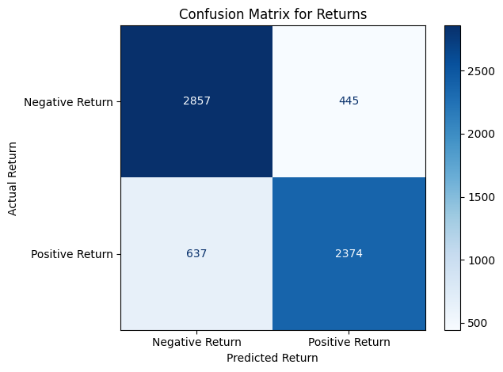

```python
print("Confusion Matrix")
print(confusion_matrix(y, ypred))
disp = ConfusionMatrixDisplay.from_predictions(y, ypred,
                              display_labels =["Negative Return","Positive Return"],
                                              cmap = plt.cm.Blues)
plt.title("Confusion Matrix for Returns")
plt.xlabel("Predicted Return")
plt.ylabel("Actual Return")
plt.tight_layout()
plt.show()
```

```python
print(classification_report(y, ypred, labels = ["0","1"]))
```

```
              precision    recall  f1-score   support

           0       0.82      0.87      0.84      3302
           1       0.84      0.79      0.81      3011

   micro avg       0.83      0.83      0.83      6313
   macro avg       0.83      0.83      0.83      6313
weighted avg       0.83      0.83      0.83      6313
```

### References:

This code was referenced from 451 Financial Engineering: Programming Assignment 1 jump start code provided by Thomas W. Miller, June 18, 2025